# Упражнение 5

## Перекрёстная проверка по отдельным наблюдениям (LOOCV)

Это самый затратный в вычислительном плане метод, но и самый надёжный в плане оценки ошибки вне выборки. Попробуем применить его к линейной модели.

```r
# подгонка линейной модели на обучающей выборке
fit.glm <- glm(mpg ~ weight + displacement + horsepower, data = DF.auto)
# считаем LOOCV-ошибку
cv.err <- cv.glm(DF.auto, fit.glm)
# результат: первое число -- по формуле LOOCV-ошибки,
#  второе -- с поправкой на смещение
cv.err$delta[1]
```

```
## [1] 18.18429
```

Теперь оценим точность полиномиальных моделей, меняя степень, в которой стоит регрессор.

```r
# вектор с LOOCV-ошибками
cv.err.loocv <- rep(0, 5)
# имена элементов вектора
names(cv.err.loocv) <- 1:5
# цикл по степеням полиномов
for (i in 1:5) {
  # оценка модели
  fit.glm <- glm(mpg ~ poly(weight, i)  + poly(displacement, i) + poly(horsepower, i), data = DF.auto)
  # расчёт ошибки
  cv.err.loocv[i] <- cv.glm(DF.auto, fit.glm)$delta[1]
}
# результат
cv.err.loocv
```

```
##        1        2        3        4        5
## 18.18429 15.54735 15.70430 15.52171 15.50202
```

## k-кратная перекрёстная проверка

K-кратная кросс-валидация – компромисс между методом проверочной выборки и LOOCV. Оценка ошибки вне выборки ближе к правде, по сравнению с проверочной выборкой, а объём вычислений меньше, чем при LOOCV. Проведём 10-ти кратную и 5-ти кратную кросс-валидацию моделей разных степеней.

# 5-ти кратная

```r
# оценим точность полиномиальных моделей, меняя степень
# вектор с ошибками по 5-ти кратной кросс-валидации
cv.err.k.fold5 <- rep(0, 5)
# имена элементов вектора
names(cv.err.k.fold5) <- 1:5
# цикл по степеням полиномов
for (i in 1:5) {
  # оценка модели
  fit.glm <- glm(mpg ~ poly(weight, i) + poly(displacement, i) + poly(horsepower, i), data = DF.auto)
  # расчёт ошибки
  cv.err.k.fold5[i] <- cv.glm(DF.auto, fit.glm, K = 5)$delta[1]
}
# результат
cv.err.k.fold5
```

```
##        1        2        3        4        5
## 18.02012 15.92669 15.46673 15.99457 15.39077
```

# 10-ти кратная

```r
# оценим точность полиномиальных моделей, меняя степень
# вектор с ошибками по 10-кратной кросс-валидации
cv.err.k.fold10 <- rep(0, 5)
# имена элементов вектора
names(cv.err.k.fold10) <- 1:5
# цикл по степеням полиномов
for (i in 1:5) {
  # оценка модели
  fit.glm <- glm(mpg ~ poly(weight, i) + poly(displacement, i) + poly(horsepower, i), data = DF.auto)
  # расчёт ошибки
  cv.err.k.fold10[i] <- cv.glm(DF.auto, fit.glm, K = 10)$delta[1]
}
# результат
cv.err.k.fold10
```

```
##        1        2        3        4        5
## 18.17526 15.62253 15.89878 15.67511 15.73372
```

Объединим все ошибки в одну таблицу и отсортируем её по возрастанию MSE (с непрерывными) и MSE.1 (со всеми обяняющими переменными):

```r
# записываем все ошибки в таблицу
df.MSE <- data.frame(Модель = c('Линейная', 'Полином 2 степени',
                                'Полином 3 степени',
                                rep(paste('Полином', 1:5, 'степени'), 3)),
                     Проверка.точности = c(rep('Проверочная выборка 50%', 3),
                                           rep('LOOCV', 5),
                                           rep('Кросс-валидация, k = 5', 5),
                                           rep('Кросс-валидация, k = 10', 5)),
                     MSE = round(c(MSE.lm.1, MSE.lm.2, MSE.lm.3,
                                  cv.err.loocv, cv.err.k.fold10, cv.err.k.fold5), 2),
                     MSE = round(c(MSE.lm.1_1, MSE.lm.2_1, MSE.lm.3_1,
                                  cv.err.loocv_1, cv.err.k.fold10_1, cv.err.k.fold5_1), 2))
# все модели по возрастанию ошибки
df.MSE[order(df.MSE$MSE), ]
```

[output not shown]

# Бутстреп

## Точность оценки параметра регрессии

При построении модели регрессии проблемы в остатках приводят к неверной оценке ошибок параметров. Обойти эту проблему можно, применив для расчёта этих ошибок бутстреп.

```r
# Оценивание точности линейной регрессионной модели ----------------------------
# оценить стандартные ошибки параметров модели
#  mpg = beta_0 + beta_1 * horsepower с помощью бутстрепа,
#  сравнить с оценками ошибок по МНК
# функция для расчёта коэффициентов ПЛР по выборке из данных
boot.fn <- function(data, index){
  coef(lm(mpg ~ weight + displacement + horsepower, data = data, subset = index))
}
boot.fn(DF.auto, 1:n)
```

```
##  (Intercept)       weight displacement   horsepower
## 44.855935695 -0.005351593 -0.005768819 -0.041674144
```

# применениe функции к бутстреп-выборке

```r
set.seed(my.seed)
boot.fn(DF.auto, sample(n, n, replace = T))
```

```
##  (Intercept)       weight displacement   horsepower
## 45.215843619 -0.005722873  0.008355697 -0.062883979
```

применяем функцию boot для вычисления стандартных ошибок параметров

```r
#  (1000 выборок с повторами)
boot(DF.auto, boot.fn, 1000)
```

```
##
## ORDINARY NONPARAMETRIC BOOTSTRAP
##
##
## Call:
## boot(data = DF.auto, statistic = boot.fn, R = 1000)
##
##
## Bootstrap Statistics :
##         original        bias     std. error
## t1* 44.855935695  1.878111e-02 1.2455805395
## t2* -0.005351593 -6.791646e-07 0.0006433027
## t3* -0.005768819 -2.539414e-04 0.0071871187
## t4* -0.041674144  2.557732e-04 0.0151751128
```

сравним с ошибками параметров по МНК

```r
# К
summary(fit.lm.1)$coef
```

```
##                 Estimate Std. Error   t value     Pr(>|t|)
## (Intercept)  48.56306139 1.78117920 27.264557 6.196798e-68
## weight       -0.00640018 0.00116012 -5.516827 1.106236e-07
## displacement  0.01314070 0.01000174  1.313842 1.904670e-01
## horsepower   -0.07777364 0.01911830 -4.068021 6.918117e-05
```

```r
summary(fit.lm.1_1)$coef
```

```
##                  Estimate  Std. Error   t value     Pr(>|t|)
## (Intercept)  45.373528912 1.898275525 23.902499 3.595651e-59
## weight       -0.006155704 0.001138084 -5.408832 1.892513e-07
## displacement  0.029356540 0.010668833  2.751617 6.504359e-03
## horsepower   -0.098337476 0.019191531 -5.124004 7.320257e-07
## origin2       2.889924808 1.011570283  2.856870 4.754992e-03
## origin3       3.946805507 1.012530903  3.897961 1.344067e-04
```

график остатков модели

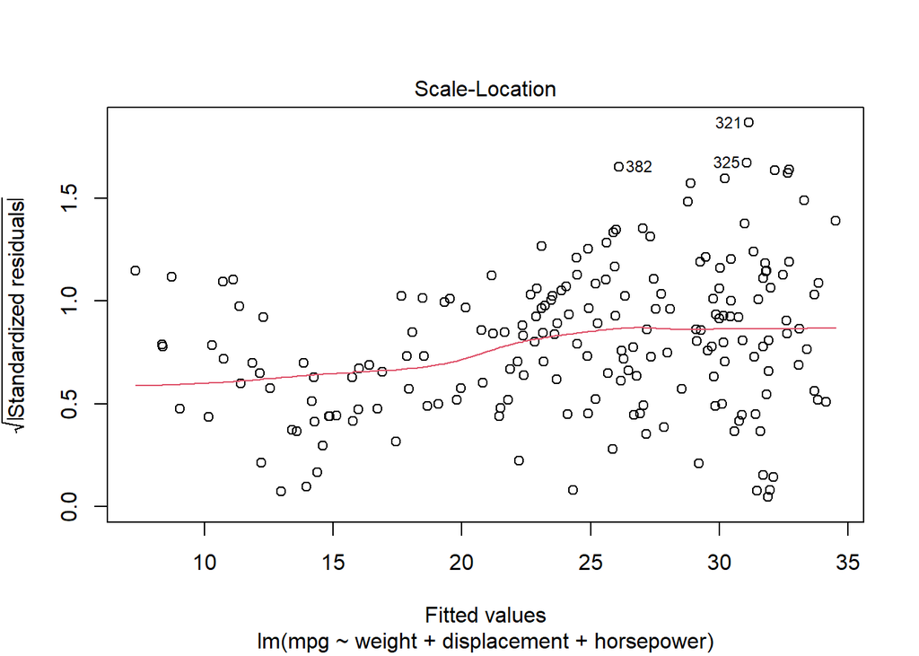

```r
plot(fit.lm.1, 3)
```

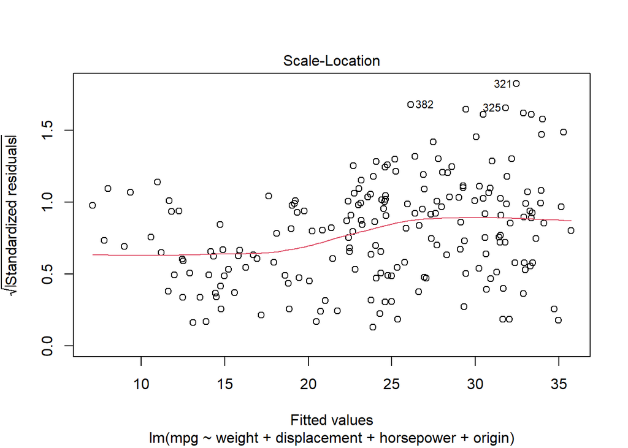

```r
plot(fit.lm.1_1, 3)
```

```r
# вычислим оценки параметров квадратичной модели регрессии
boot.fn.2 <- function(data, index){
  coef(lm(mpg ~ poly(weight, 2) + poly(displacement, 2) +  poly(horsepower, 2), data = data, subset = index))
}
# применим функцию к 1000 бутсреп-выборкам
set.seed(my.seed)
boot(DF.auto, boot.fn.2, 1000)
```

```
##
## ORDINARY NONPARAMETRIC BOOTSTRAP
##
##
## Call:
## boot(data = DF.auto, statistic = boot.fn.2, R = 1000)
##
##
## Bootstrap Statistics :
##       original       bias    std. error
## t1*  23.445918  0.006172718   0.1948812
## t2* -53.482065 -0.495671705  12.5919641
## t3*   8.103826  0.021082846   5.5406525
## t4* -20.143267 -0.214836732  13.5629784
## t5*  17.738459  0.001432925   7.6242467
## t6* -59.395825  0.850473690  12.0406922
## t7*  15.778959 -0.040055118   6.4898747
```

сравним с ошибками параметров по МНК

```r
summary(fit.lm.2)$coef
```

```
##                          Estimate Std. Error    t value      Pr(>|t|)
## (Intercept)             23.820013  0.2984167 79.8213253 1.566265e-147
## poly(weight, 2)1       -63.765840 19.9954903 -3.1890111  1.671249e-03
## poly(weight, 2)2         2.977737  9.3569596  0.3182377  7.506560e-01
## poly(displacement, 2)1   8.142977 19.4930338  0.4177378  6.766130e-01
## poly(displacement, 2)2  13.221090 11.1222667  1.1887046  2.360473e-01
## poly(horsepower, 2)1   -77.060593 14.7519824 -5.2237449  4.605742e-07
## poly(horsepower, 2)2    26.966756  8.5746295  3.1449471  1.929713e-03
```

```r
summary(fit.lm.2_1)$coef
```

```
##                          Estimate Std. Error    t value      Pr(>|t|)
## (Intercept)             22.788967  0.4769486 47.7807594 9.601860e-107
## poly(weight, 2)1       -65.312471 20.2137057 -3.2310983  1.457189e-03
## poly(weight, 2)2         1.894751  9.2140103  0.2056380  8.372974e-01
## poly(displacement, 2)1  32.728250 21.7759255  1.5029557  1.345374e-01
## poly(displacement, 2)2   4.125310 11.4774672  0.3594268  7.196813e-01
## poly(horsepower, 2)1   -83.664238 14.5985955 -5.7309786  3.939958e-08
## poly(horsepower, 2)2    31.165578  8.5068982  3.6635654  3.237882e-04
## origin2                  1.666080  1.0263434  1.6233162  1.062064e-01
## origin3                  3.259359  1.0192968  3.1976547  1.627149e-03
```

график остатков модели

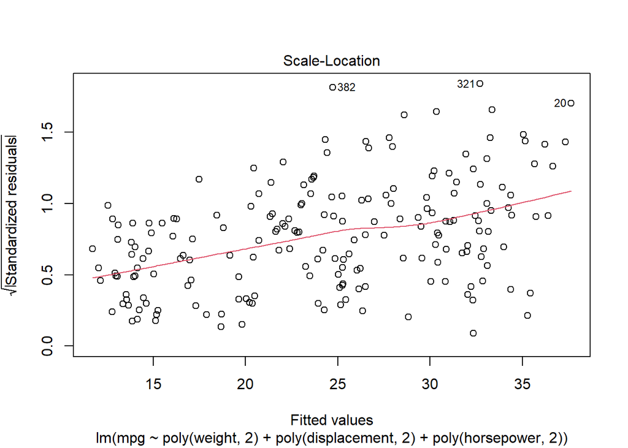

```r
plot(fit.lm.2, 3)
```

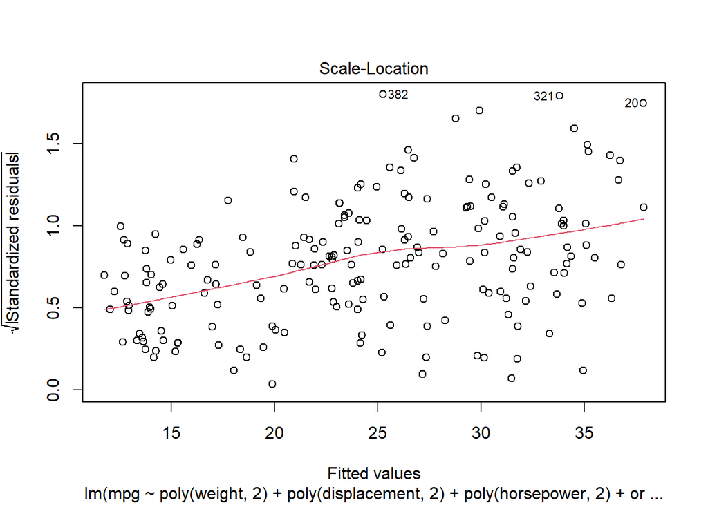

```r
plot(fit.lm.2_1, 3)
```